# Introduction to tidylda

Tommy Jones

2026-09-10

Note: for code examples, see README.md

# Introduction to the `tidylda` package

`tidylda` implements Latent Dirichlet Allocation using style conventions from the [tidyverse](https://style.tidyverse.org/) and [tidymodels](https://tidymodels.github.io/model-implementation-principles/). `tidylda`’s sampler is written in C++ for performance and offers several novel features. Fitting uses [warpLDA](https://arxiv.org/abs/1510.08628), a Metropolis-Hastings sampler that alternates document-ordered and word-ordered passes so that each pass touches only a small, cache-resident working set; it replaced collapsed Gibbs sampling in version 0.1.0 and is multithreaded, with results that do not depend on the number of threads. It also has methods for sampling from the posterior of a trained model, for more traditional Bayesian analyses.

*tidylda*’s sampler has several unique features, described below.

**Non-uniform initialization:** Most LDA samplers initialize by assigning words to topics and topics to documents (i.e., construct the $\boldsymbol{Cd}$ and $\boldsymbol{Cv}$ matrices) by sampling from a uniform distribution. This ensures initialization without incorporating any prior information. *tidylda* incorporates the priors in its initialization. It begins by drawing $P(\text{topic}|\text{document})$ and $P(\text{word}|\text{topic})$ from Dirichlet distributions with parameters $\boldsymbol\alpha$ and $\boldsymbol\eta$, respectively. Then *tidylda* uses the above probabilities to construct $P(\text{topic}|\text{word}, \text{document})$ and makes a single sampling pass to initialize $\boldsymbol{Cd}$ and $\boldsymbol{Cv}$. This non-uniform initialization powers transfer learning with LDA (tLDA), described elsewhere, by starting sampling near where the previous run left off. For initial models, it uses the user’s prior information to tune where sampling starts.

**Flexible priors:** *tidylda* has multiple options for setting LDA priors. Users may set scalar values for $\boldsymbol\alpha$ and $\boldsymbol\eta$ to construct symmetric priors. Users may also choose to construct vector priors for both $\boldsymbol\alpha$ and $\boldsymbol\eta$ for a full specification of LDA. Additionally, *tidylda* allows users to set a matrix prior for $\boldsymbol\eta$, enabled by its implementation of tLDA. This lets users to set priors over word-topic relationships informed by expert input. The best practices for encoding expert input in this manner are not yet well studied. Nevertheless, this capability makes *tidylda* unique among LDA implementations.

**Burn in iterations and posterior averaging:** Most LDA samplers construct posterior estimates of $\boldsymbol\Theta$ and $\boldsymbol{B}$ from $\boldsymbol{Cd}$ and $\boldsymbol{Cv}$’s values of the final iteration of sampling, effectively using a single sample. This is inconsistent with best practices from Bayesian statistics, which is to average over many samples from a stable posterior. *tidylda* enables averaging across multiple samples of the posterior with the `burnin` argument. When `burnin` is set to a positive integer, *tidylda* averages the posterior across all iterations larger than `burnin`. For example, if `iterations` is 200 and `burnin` is 150, *tidylda* will return a posterior estimate that is an average of the last 50 sampling iterations. This ensures that posterior estimates are more likely to be representative than any single sample.

**Transfer learning with tLDA:** Finally, *tidylda*’s sampler enables transfer learning with tLDA. The full specification of tLDA and details on its implementation in *tidylda* are described briefly in the tLDA vignette and more thoroughly in forthcoming research.

### Tidy Methods

*tidylda*’s construction follows *Conventions of R Modeling Packages* [@tidymodelsbook]. In particular, it contains methods for `print`, `summary`, `glance`, `tidy`, and `augment`, consistent with other “tidy” packages. These methods are briefly described below.

- `print`, `summary`, and `glance` return various summaries of the contents of a `tidylda` object, into which an LDA model trained with *tidylda* is stored.
- `tidy` returns the contents of $\boldsymbol\Theta$, $\boldsymbol{B}$, or $\boldsymbol\Lambda$ (stored as `theta`, `beta`, and `lambda` respectively), as specified by the user, formatted as a tidy `tibble`, instead of a numeric matrix.
- `augment` appends model outputs to observational-level data. Taking the cue from [*tidytext*](https://github.com/juliasilge/tidytext), “observational-level” data is one row per word per document. Therefore, the key statistic used by `augment` is $P(\text{topic}|\text{word}, \text{document})$. *tidylda* calculates this as $\boldsymbol\Lambda \times P(\text{word}|\text{document})$, where $P(\text{word}|\text{document}_d) = \frac{\boldsymbol{x}_d}{\sum_{v=1}^V x_{d,v}}$.

### Other Notable Features

*tidylda* has three evaluation metrics for topic models, two goodness-of-fit measures—$R^2$ as implemented from [*mvrsquared*](https://cran.r-project.org/package=mvrsquared) and the log likelihood of the model given the data—and one coherence measure—probabilistic coherence. A flag set during model fitting with `calc_r2 = TRUE`[^1] will return a model with an $R^2$ statistic. Similarly, the log likelihood of the model, given the data, is calculated at each sampling iteration if the user selects `calc_likelihood = TRUE` during model fitting.

The coherence measure is called probabilistic coherence. (See vignette on probabilistic coherence.) Probabilistic coherence is bound between -1 and 1. Values near zero indicate that the top words in a topic are statistically independent from each other. Positive values indicate that the top words in a topic are positively correlated in a statistically-dependent manner. Negative values indicate that the words in a topic are negatively correlated with each other in a statistically-dependent manner. (In practice, negative values tend to be very near zero.)

*tidylda* enables traditional Bayesian uncertainty quantification by sampling from the posterior. The posterior distribution for $\boldsymbol\theta_d$ is $\text{Dirichlet}(\boldsymbol{Cd}_d + \boldsymbol\alpha)$ and the posterior distribution for $\boldsymbol\beta_k$ is $\text{Dirichlet}(\boldsymbol{Cv}_k + \boldsymbol\eta)$ (or $\text{Dirichlet}(\boldsymbol{Cv}_k + \boldsymbol\eta_k)$ for tLDA). *tidylda* enables a `posterior` method for `tidylda` objects, allowing users to sample from the posterior to quantify uncertainty for estimates of estimated parameters.

## Discussion

While many other topic modeling packages exist, *tidylda* is very user friendly and brings novel features. Its user friendliness comes from compatibility with the tidyverse. And *tidylda* includes tLDA and other methods contained in the previous chapters of this dissertation. It also has methods for sampling from the posterior of a trained model, for more traditional Bayesian analyses. *tidylda*’s sampler is written in C++ for performance.

## Installation

You can install the development version from [GitHub](https://github.com/) with:

```r
install.packages("remotes")

remotes::install_github("tommyjones/tidylda")
```

## Example

```r
library(tidytext)
library(dplyr)
```

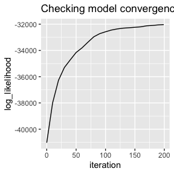

```r
library(ggplot2)
library(tidyr)
library(tidylda)
library(Matrix)
### Initial set up ---
# load some documents
docs <- nih_sample

# tokenize using tidytext's unnest_tokens
tidy_docs <- docs |>
  select(APPLICATION_ID, ABSTRACT_TEXT) |>
  unnest_tokens(output = word,
                input = ABSTRACT_TEXT,
                stopwords = stop_words$word,
                token = "ngrams",
                n_min = 1, n = 2) |>
  count(APPLICATION_ID, word) |>
  filter(n>1) #Filtering for words/bigrams per document, rather than per corpus

tidy_docs <- tidy_docs |> # filter words that are just numbers
  filter(! stringr::str_detect(tidy_docs$word, "^[0-9]+$"))

# append observation level data
colnames(tidy_docs)[1:2] <- c("document", "term")


# turn a tidy tbl into a sparse dgCMatrix
# note tidylda has support for several document term matrix formats
d <- tidy_docs |>
  cast_sparse(document, term, n)

# let's split the documents into two groups to demonstrate predictions and updates
d1 <- d[1:50, ]

d2 <- d[51:nrow(d), ]

# make sure we have different vocabulary for each data set to simulate the "real world"
# where you get new tokens coming in over time
d1 <- d1[, colSums(d1) > 0]

d2 <- d2[, colSums(d2) > 0]

### fit an intial model and inspect it ----
set.seed(123)

lda <- tidylda(
  data = d1,
  k = 10,
  iterations = 200,
  burnin = 175,
  alpha = 0.1, # also accepts vector inputs
  eta = 0.05, # also accepts vector or matrix inputs
  optimize_alpha = FALSE, # experimental
  calc_likelihood = TRUE,
  calc_r2 = TRUE, # see https://arxiv.org/abs/1911.11061
  return_data = FALSE
)

# did the model converge?
# there are actual test stats for this, but should look like "yes"
qplot(x = iteration, y = log_likelihood, data = lda$log_likelihood, geom = "line") +
    ggtitle("Checking model convergence")
```

```r
# look at the model overall
glance(lda)
```

```
## # A tibble: 1 × 5
##   num_topics num_documents num_tokens iterations burnin
##        <int>         <int>      <int>      <dbl>  <dbl>
## 1         10            50       1524        200    175
```

```r
print(lda)
```

```
## A Latent Dirichlet Allocation Model of  10 topics,  50  documents, and  1524  tokens:
## tidylda(data = d1, k = 10, iterations = 200, burnin = 175, alpha = 0.1,
##     eta = 0.05, optimize_alpha = FALSE, calc_likelihood = TRUE,
##     calc_r2 = TRUE, return_data = FALSE)
##
## The model's R-squared is  0.259
## The  5  most prevalent topics are:
## # A tibble: 10 × 4
##   topic prevalence coherence top_terms
##   <dbl>      <dbl>     <dbl> <chr>
## 1     2       11.9     0.201 research, disparities, program, extinction, center…
## 2     7       11.8     0.208 cancer, dcis, imaging, clinical, breast, ...
## 3     9       10.8     0.202 imaging, data, cells, ppg, core, ...
## 4     3       10.8     0.277 cell, cells, specific, lung, human, ...
## 5     6       10.6     0.528 diabetes, risk, sud, numeracy, related, ...
## # ℹ 5 more rows
##
## The  5  most coherent topics are:
## # A tibble: 10 × 4
##   topic prevalence coherence top_terms
##   <dbl>      <dbl>     <dbl> <chr>
## 1     6      10.6      0.528 diabetes, risk, sud, numeracy, related, ...
## 2     8       9.25     0.371 cmybp, injury, function, mitochondrial, fragment, …
## 3     5       9.23     0.298 sleep, sz, memory, studies, power, ...
## 4     3      10.8      0.277 cell, cells, specific, lung, human, ...
## 5     1       8.64     0.272 v4, effects, stiffening, wall, activity, ...
## # ℹ 5 more rows
```

```r
# it comes with its own summary matrix that's printed out with print(), above
lda$summary
```

```
## # A tibble: 10 × 4
##    topic prevalence coherence top_terms
##    <dbl>      <dbl>     <dbl> <chr>
##  1     1       8.64     0.272 v4, effects, stiffening, wall, activity, ...
##  2     2      11.9      0.201 research, disparities, program, extinction, cente…
##  3     3      10.8      0.277 cell, cells, specific, lung, human, ...
##  4     4       8.19     0.163 cns, cdk5, nmdar, based, lsds, ...
##  5     5       9.23     0.298 sleep, sz, memory, studies, power, ...
##  6     6      10.6      0.528 diabetes, risk, sud, numeracy, related, ...
##  7     7      11.8      0.208 cancer, dcis, imaging, clinical, breast, ...
##  8     8       9.25     0.371 cmybp, injury, function, mitochondrial, fragment,…
##  9     9      10.8      0.202 imaging, data, cells, ppg, core, ...
## 10    10       8.75     0.182 plasticity, function, redox, cellular, ros, ...
```

```r
# inspect the individual matrices
tidy_theta <- tidy(lda, matrix = "theta")

tidy_theta
```

```
## # A tibble: 500 × 3
##    document topic   theta
##    <chr>    <dbl>   <dbl>
##  1 8574224      1 0.00238
##  2 8574224      2 0.00238
##  3 8574224      3 0.00238
##  4 8574224      4 0.00238
##  5 8574224      5 0.00238
##  6 8574224      6 0.139
##  7 8574224      7 0.00333
##  8 8574224      8 0.00238
##  9 8574224      9 0.00238
## 10 8574224     10 0.841
## # ℹ 490 more rows
```

```r
tidy_beta <- tidy(lda, matrix = "beta")

tidy_beta
```

```
## # A tibble: 15,240 × 3
##    topic token             beta
##    <dbl> <chr>            <dbl>
##  1     1 adolescence  0.0000833
##  2     1 age          0.0000833
##  3     1 application  0.0000833
##  4     1 depressive   0.0000833
##  5     1 disorder     0.0000833
##  6     1 emotionality 0.0000833
##  7     1 information  0.00335
##  8     1 mdd          0.0000833
##  9     1 onset        0.0000833
## 10     1 onset mdd    0.0000833
## # ℹ 15,230 more rows
```

```r
tidy_lambda <- tidy(lda, matrix = "lambda")

tidy_lambda
```

```
## # A tibble: 15,240 × 3
##    topic token         lambda
##    <dbl> <chr>          <dbl>
##  1     1 adolescence  0.00754
##  2     1 age          0.00909
##  3     1 application  0.00762
##  4     1 depressive   0.0200
##  5     1 disorder     0.0200
##  6     1 emotionality 0.0200
##  7     1 information  0.267
##  8     1 mdd          0.0111
##  9     1 onset        0.00756
## 10     1 onset mdd    0.0200
## # ℹ 15,230 more rows
```

```r
# append observation-level data
augmented_docs <- augment(lda, data = tidy_docs)
augmented_docs
```

```
## # A tibble: 4,566 × 4
##    document term            n topic
##    <chr>    <chr>       <int> <int>
##  1 8574224  adolescence     1     6
##  2 8646901  adolescence     1     6
##  3 8689019  adolescence     1     6
##  4 8705323  adolescence     1     6
##  5 8574224  age             1    10
##  6 8705323  age             1    10
##  7 8757072  age             1    10
##  8 8823186  age             1    10
##  9 8574224  application     1    10
## 10 8605875  application     1    10
## # ℹ 4,556 more rows
```

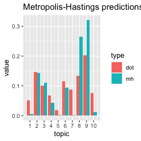

```r
### predictions on held out data ---
# two methods: mh (Metropolis-Hastings) is cleaner and more technically
# correct in the bayesian sense
p_mh <- predict(lda, new_data = d2[1, ], iterations = 100, burnin = 75)

# dot is faster, less prone to error (e.g. underflow), noisier, and frequentist
p_dot <- predict(lda, new_data = d2[1, ], method = "dot")

# pull both together into a plot to compare
tibble(topic = 1:ncol(p_mh), mh = p_mh[1,], dot = p_dot[1, ]) |>
  pivot_longer(cols = mh:dot, names_to = "type") |>
  ggplot() +
  geom_bar(mapping = aes(x = topic, y = value, group = type, fill = type),
           stat = "identity", position="dodge") +
  scale_x_continuous(breaks = 1:10, labels = 1:10) +
  ggtitle("Metropolis-Hastings predictions vs. dot product predictions")
```

```r
### Augment as an implicit prediction using the 'dot' method ----
# Aggregating over terms results in a distribution of topics over documents
# roughly equivalent to using the "dot" method of predictions.
augment_predict <-
  augment(lda, tidy_docs, "prob") |>
  group_by(document) |>
  select(-c(document, term)) |>
  summarise_all(function(x) sum(x, na.rm = T))
```

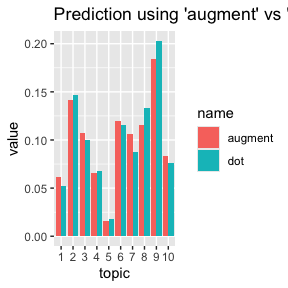

```r
# reformat for easy plotting
augment_predict <-
  as_tibble(t(augment_predict[, -c(1,2)]), .name_repair = "minimal")

colnames(augment_predict) <- unique(tidy_docs$document)

augment_predict$topic <- 1:nrow(augment_predict) |> as.factor()

compare_mat <-
  augment_predict |>
  select(
    topic,
    augment = matches(rownames(d2)[1])
  ) |>
  mutate(
    augment = augment / sum(augment), # normalize to sum to 1
    dot = p_dot[1, ]
  ) |>
  pivot_longer(cols = c(augment, dot))

ggplot(compare_mat) +
  geom_bar(aes(y = value, x = topic, group = name, fill = name),
           stat = "identity", position = "dodge") +
  labs(title = "Prediction using 'augment' vs 'predict(..., method = \"dot\")'")
```

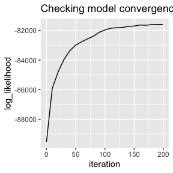

```r
# Not shown: aggregating over documents results in recovering the "tidy" lambda.

### updating the model ----
# now that you have new documents, maybe you want to fold them into the model?
lda2 <- refit(
  object = lda,
  new_data = d, # save me the trouble of manually-combining these by just using d
  iterations = 200,
  burnin = 175,
  calc_likelihood = TRUE,
  calc_r2 = TRUE
)

# we can do similar analyses
# did the model converge?
qplot(x = iteration, y = log_likelihood, data = lda2$log_likelihood, geom = "line") +
  ggtitle("Checking model convergence")
```

```r
# look at the model overall
glance(lda2)
```

```
## # A tibble: 1 × 5
##   num_topics num_documents num_tokens iterations burnin
##        <int>         <int>      <int>      <dbl>  <dbl>
## 1         10            99       2962        200    175
```

```r
print(lda2)
```

```
## A Latent Dirichlet Allocation Model of  10 topics,  99  documents, and  2962  tokens:
## refit.tidylda(object = lda, new_data = d, iterations = 200, burnin = 175,
##     calc_likelihood = TRUE, calc_r2 = TRUE)
##
## The model's R-squared is  0.1429
## The  5  most prevalent topics are:
## # A tibble: 10 × 4
##   topic prevalence coherence top_terms
##   <dbl>      <dbl>     <dbl> <chr>
## 1     2      17.4      0.152 research, program, core, health, training, ...
## 2     3      13.3      0.192 cell, cells, human, lung, specific, ...
## 3     9      10.8      0.159 data, imaging, infection, immune, response, ...
## 4     6      10.4      0.207 risk, diabetes, factors, sud, related, ...
## 5     7       9.55     0.143 cancer, clinical, dcis, brain, breast, ...
## # ℹ 5 more rows
##
## The  5  most coherent topics are:
## # A tibble: 10 × 4
##   topic prevalence coherence top_terms
##   <dbl>      <dbl>     <dbl> <chr>
## 1     8       6.78     0.328 cmybp, function, injury, mitochondrial, fragment, …
## 2    10       6.91     0.236 plasticity, function, cellular, redox, determine, …
## 3     6      10.4      0.207 risk, diabetes, factors, sud, related, ...
## 4     3      13.3      0.192 cell, cells, human, lung, specific, ...
## 5     1       7.96     0.190 clinical, muscle, wall, v4, effects, ...
## # ℹ 5 more rows
```

```r
# how does that compare to the old model?
print(lda)
```

```
## A Latent Dirichlet Allocation Model of  10 topics,  50  documents, and  1524  tokens:
## tidylda(data = d1, k = 10, iterations = 200, burnin = 175, alpha = 0.1,
##     eta = 0.05, optimize_alpha = FALSE, calc_likelihood = TRUE,
##     calc_r2 = TRUE, return_data = FALSE)
##
## The model's R-squared is  0.259
## The  5  most prevalent topics are:
## # A tibble: 10 × 4
##   topic prevalence coherence top_terms
##   <dbl>      <dbl>     <dbl> <chr>
## 1     2       11.9     0.201 research, disparities, program, extinction, center…
## 2     7       11.8     0.208 cancer, dcis, imaging, clinical, breast, ...
## 3     9       10.8     0.202 imaging, data, cells, ppg, core, ...
## 4     3       10.8     0.277 cell, cells, specific, lung, human, ...
## 5     6       10.6     0.528 diabetes, risk, sud, numeracy, related, ...
## # ℹ 5 more rows
##
## The  5  most coherent topics are:
## # A tibble: 10 × 4
##   topic prevalence coherence top_terms
##   <dbl>      <dbl>     <dbl> <chr>
## 1     6      10.6      0.528 diabetes, risk, sud, numeracy, related, ...
## 2     8       9.25     0.371 cmybp, injury, function, mitochondrial, fragment, …
## 3     5       9.23     0.298 sleep, sz, memory, studies, power, ...
## 4     3      10.8      0.277 cell, cells, specific, lung, human, ...
## 5     1       8.64     0.272 v4, effects, stiffening, wall, activity, ...
## # ℹ 5 more rows
```

[^1]: Users can calculate $R^2$ after a model is fit by using the *mvrsquared* package or calling `tidylda:::calc_lda_rsquared`. `calc_lda_rsquared` is an internal function to *tidylda*, requiring the package name followed by three colons, as is R’s standard.